#### **To: Prof. Green**

#### **From: Michael Scott**

#### **Date: 04/15/2020**

#### **RE: Orange Juice Purchase Analysis**

Over the course of 1070 unique observations we have uncovered interesting trends regarding the purchase habits of orange juice consumers. 653 of the 1070 customers ended up buying the Citrus Hill brand, while the remaining 417 customers purchased the Minute Maid brand. The data also showed that the Minute Maid brand had consistently higher prices as compared to its competitor.

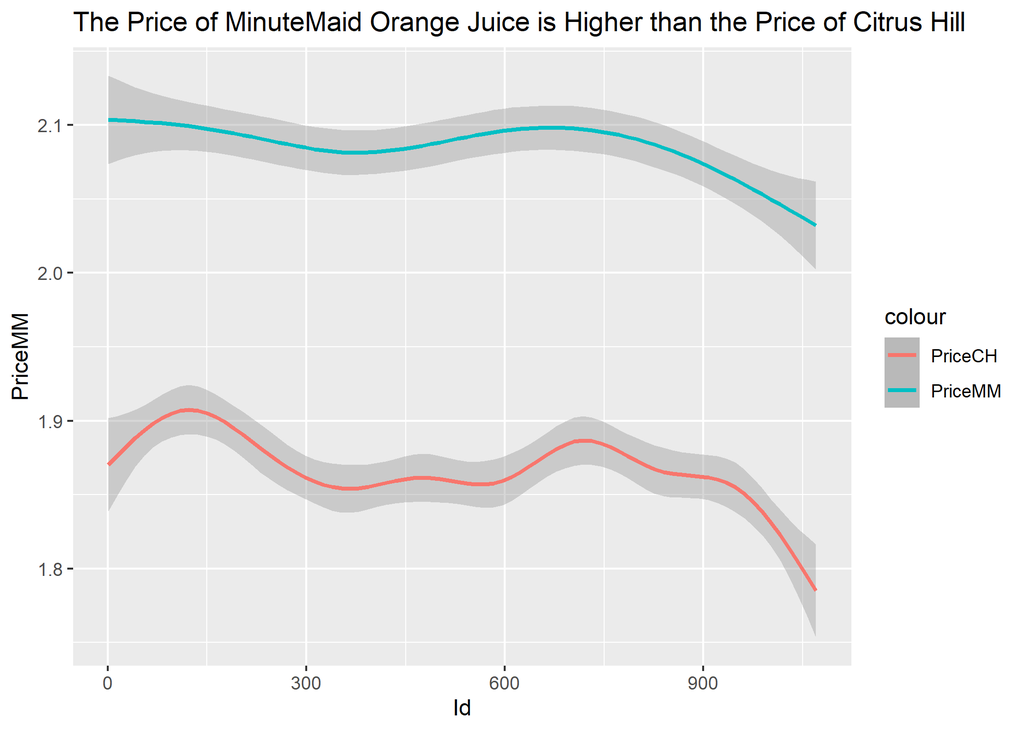

It appears that orange juice has a high level of price elasticity, with the higher priced item recieving the lower amount of purchases. Citrus Hill, with their average price of $1.867, made around $360.97 more over the 1070 observations than their competitors, who had an average price of $2.085.

Please do not hesitate to contact me if you have questions or would like to discuss the analysis further, it is best to reach me at scottmichael@seattleu.edu. I can also provide the Technical Appendix with my complete analysis and the data if you would like more detail.

Best regards,

Michael